# Module: API-KMA forecast

LearningSpoonsR

2018-05-13

동네예보조회 (Internet Explorer를 사용하세요.)

## 1. Query 준비

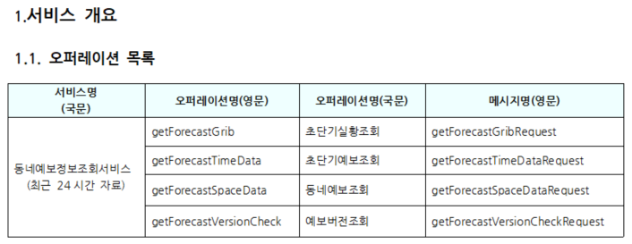

> [그림 1] 활용가이드.hwp 스크린샷

위의 [그림1] 처럼 4가지의 오퍼레이션을 제공합니다.

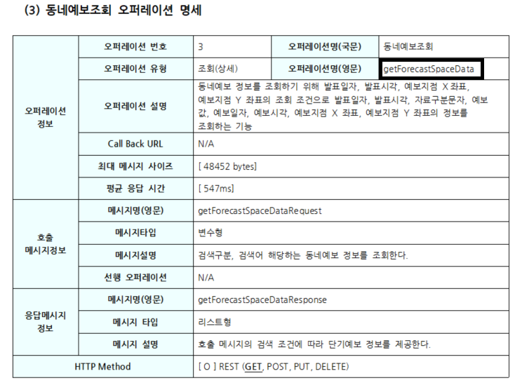

> [그림 2] 활용가이드.hwp 스크린샷

위의 [그림2]은 오퍼레이션의 개요를 설명합니다.

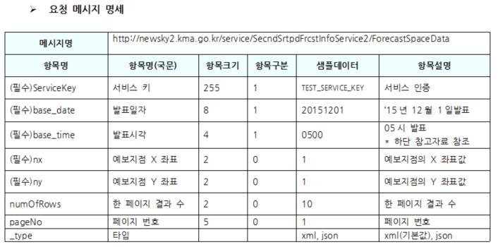

> [그림 3] 활용가이드.hwp 스크린샷

위의 요청메시지를 작성하여 API database에 접속합니다. 아래의 코드블럭으로 이를 구성해보겠습니다.

```r
svc_key <- paste0("uEID6no5WOeFLEu%2FYZpdjKHQVrE2HtFEig4lJ7iHWiE5w",
                  "GS1L3RvmusPMDkumoj8f%2BSffvPYWO%2B5xXu%2FrQ%2Bvzg%3D%3D")
today   <- gsub("-", "", Sys.Date())
url     <- paste0("http://newsky2.kma.go.kr/service/SecndSrtpdFrcstInfoService2",
                  "/ForecastSpaceData")
fields  <- c("ServiceKey", "base_date", "base_time", "nx", "ny" , "_type")
values  <- c(svc_key     , today      , "0800"     , "60", "127", "json")
request <- paste(fields, values, sep = "=") %>% paste(collapse="&")
query   <- paste0(url, "?", request)
cat(query)
```

```
## http://newsky2.kma.go.kr/service/SecndSrtpdFrcstInfoService2/ForecastSpaceData?ServiceKey=uEID6no5WOeFLEu%2FYZpdjKHQVrE2HtFEig4lJ7iHWiE5wGS1L3RvmusPMDkumoj8f%2BSffvPYWO%2B5xXu%2FrQ%2Bvzg%3D%3D&base_date=20180513&base_time=0800&nx=60&ny=127&_type=json
```

`request`의 `fields`와 `values`는 메뉴얼과 웹사이트를 참조하여 구성해야 합니다. 특히 `nx`와 `ny`는 우리나라의 특정 지점의 좌표를 지정해주는 명령어입니다. `nx=60, ny=127`은 서울특별시, 혹은 서울특별시의 종로구와 중구의 좌표입니다.

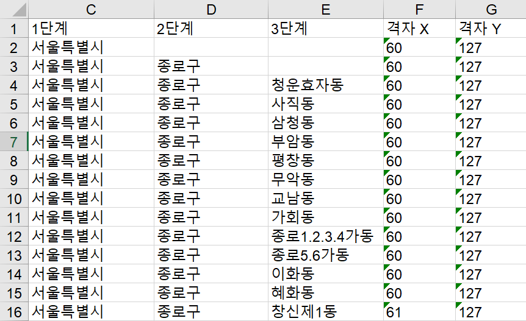

> [그림 4] 동네예보조회서비스_격자_위경도.xls 스크린샷

`url`과 `request`를 조합하여 `query`가 작성되었습니다. 위의 `query`를 웹브라우저에 긁어붙여서 결과를 확인할 수 있습니다.

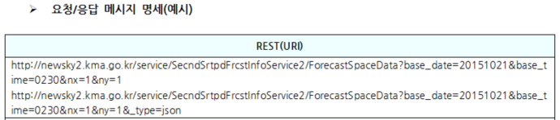

> [그림 5] 활용가이드.hwp 스크린샷

메뉴얼에서도 위의 [그림5]처럼 예시를 제공하고 있습니다.

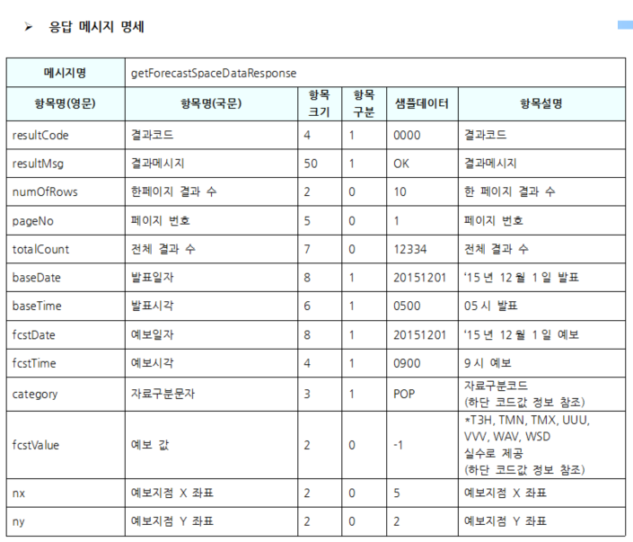

> [그림 6] 활용가이드.hwp 스크린샷

위의 [그림6]는 해당 `query`를 통해서 얻을 수 있는 정보입니다.

## 2. 데이터 프레임으로 정리

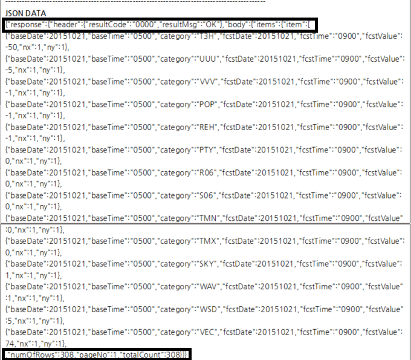

> [그림 7] 활용가이드.hwp 스크린샷

[그림7]는 json형식으로 조회를 했을때의 예상 결과입니다. 위의 `query`를 실행하여 결과를 확인해보겠습니다.

```r
raw <- readLines(query, warn = "F", encoding = "UTF-8")
print(raw)
```

```
## [1] "{\"response\":{\"header\":{\"resultCode\":\"0000\",\"resultMsg\":\"OK\"},\"body\":{\"items\":{\"item\":[{\"baseDate\":20180513,\"baseTime\":\"0800\",\"category\":\"POP\",\"fcstDate\":20180513,\"fcstTime\":1200,\"fcstValue\":10,\"nx\":60,\"ny\":127},{\"baseDate\":20180513,\"baseTime\":\"0800\…
```

데이터는 잘 불러져 왔습니다. json형식의 data를 `data.frame`으로 바꾸는 일만 남았습니다. (지금은 데이터의 이름이 `raw`이지만, `data.frame`이 되면 `dataset`이라는 이름을 붙여줄 예정입니다.)

```r
activate("jsonlite")
raw <- fromJSON(raw)
str(raw)
```

```
## List of 1
##  $ response:List of 2
##   ..$ header:List of 2
##   .. ..$ resultCode: chr "0000"
##   .. ..$ resultMsg : chr "OK"
##   ..$ body  :List of 4
##   .. ..$ items     :List of 1
##   .. .. ..$ item:'data.frame':   10 obs. of  8 variables:
##   .. .. .. ..$ baseDate : int [1:10] 20180513 20180513 20180513 20180513 20180513 20180513 20180513 20180513 20180513 20180513
##   .. .. .. ..$ baseTime : chr [1:10] "0800" "0800" "0800" "0800" ...
##   .. .. .. ..$ category : chr [1:10] "POP" "PTY" "R06" "REH" ...
##   .. .. .. ..$ fcstDate : int [1:10] 20180513 20180513 20180513 20180513 20180513 20180513 20180513 20180513 20180513 20180513
##   .. .. .. ..$ fcstTime : int [1:10] 1200 1200 1200 1200 1200 1200 1200 1200 1200 1200
##   .. .. .. ..$ fcstValue: num [1:10] 10 0 0 65 0 2 20 2.9 295 -1.4
##   .. .. .. ..$ nx       : int [1:10] 60 60 60 60 60 60 60 60 60 60
##   .. .. .. ..$ ny       : int [1:10] 127 127 127 127 127 127 127 127 127 127
##   .. ..$ numOfRows : int 10
##   .. ..$ pageNo    : int 1
##   .. ..$ totalCount: int 216
```

이제 거의 다 되었습니다. `raw`라는 객체가 조금씩 모습을 잡아가고 있습니다.

```r
dataset <- raw$response$body$items$item
dataset
```

|  | baseDate | baseTime | category | fcstDate | fcstTime | fcstValue | nx | ny |
| --- | --- | --- | --- | --- | --- | --- | --- | --- |
| 1 | 20180513 | 0800 | POP | 20180513 | 1200 | 10.0 | 60 | 127 |
| 2 | 20180513 | 0800 | PTY | 20180513 | 1200 | 0.0 | 60 | 127 |
| 3 | 20180513 | 0800 | R06 | 20180513 | 1200 | 0.0 | 60 | 127 |
| 4 | 20180513 | 0800 | REH | 20180513 | 1200 | 65.0 | 60 | 127 |
| 5 | 20180513 | 0800 | S06 | 20180513 | 1200 | 0.0 | 60 | 127 |
| 6 | 20180513 | 0800 | SKY | 20180513 | 1200 | 2.0 | 60 | 127 |
| 7 | 20180513 | 0800 | T3H | 20180513 | 1200 | 20.0 | 60 | 127 |
| 8 | 20180513 | 0800 | UUU | 20180513 | 1200 | 2.9 | 60 | 127 |
| 9 | 20180513 | 0800 | VEC | 20180513 | 1200 | 295.0 | 60 | 127 |
| 10 | 20180513 | 0800 | VVV | 20180513 | 1200 | -1.4 | 60 | 127 |

드디어 `dataset`을 만들어 냈습니다.

## 3. Get the full record!

그런데 과연 우리가 확보한 데이터가 전부인가요?

```r
raw$response$body[-1]
```

```
## $numOfRows
## [1] 10
##
## $pageNo
## [1] 1
##
## $totalCount
## [1] 216
```

저희는 10개의 관찰값을 확보했는데, 이것은 `pageNo` 1에 해당합니다. 그런데 해당 `request`에 대해서 실제 data의 갯수는 216입니다. 즉, 저희는 1번-10번 관찰값만 확보를 하였고, 11번-216번 관찰값은 확보하지 못했습니다.

`query`를 작성했던 코드블럭과 [그림3]을 다시한번 보겠습니다.

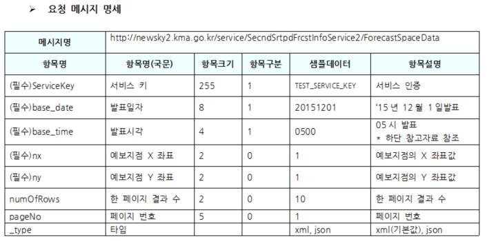

> [그림 8] 활용가이드.hwp 스크린샷

```r
svc_key <- paste0("uEID6no5WOeFLEu%2FYZpdjKHQVrE2HtFEig4lJ7iHWiE5w",
                  "GS1L3RvmusPMDkumoj8f%2BSffvPYWO%2B5xXu%2FrQ%2Bvzg%3D%3D")
today   <- gsub("-", "", Sys.Date())
url     <- paste0("http://newsky2.kma.go.kr/service/SecndSrtpdFrcstInfoService2",
                  "/ForecastSpaceData")
fields  <- c("ServiceKey", "base_date", "base_time", "nx", "ny" , "_type")
values  <- c(svc_key     , today      , "0800"     , "60", "127", "json")
request <- paste(fields, values, sep = "=") %>% paste(collapse="&")
query   <- paste0(url, "?", request)
cat(query)
```

`fields`에 `pageNo`를 1부터 22로 바꿔가면서 실행하고 그 결과를 합해야 한다는 것이 보이시나요? 이런 반복문을 만드는 작업을 해보겠습니다.

`i`라는 변수가 1,2,3,…,22의 차례로 바뀌어야 합니다. `i`가 바뀔때마다 `pageNo`에 해당하는 `values`가 바뀌어야 하고, 그 결과로 `query`가 바뀌어야 합니다.

Q. 여기에서 22라는 값은 왜 22이죠?

- A. 22*10이면 216보다 크거나 같기 때문입니다.
- `raw$response$body$totalCount`=216
- `raw$response$body$numOfRows`= 10
- `ceiling(raw$response$body$totalCount/raw$response$body$numOfRows)`

```r
maxPage <- ceiling(raw$response$body$totalCount/raw$response$body$numOfRows)
fields  <- c("ServiceKey", "base_date", "base_time", "nx", "ny" , "_type", "pageNo")
for (i in 1:maxPage) {
  print(i)
  values_i  <- c(svc_key  , today      , "0800"     , "60", "127", "json" , i)
  request_i <- paste(fields, values_i, sep = "=") %>% paste(collapse="&")
  query_i   <- paste0(url, "?", request_i)
  if (i %in% c(5,10,15)) cat(query_i)
}
```

```
## [1] 1
## [1] 2
## [1] 3
## [1] 4
## [1] 5
## http://newsky2.kma.go.kr/service/SecndSrtpdFrcstInfoService2/ForecastSpaceData?ServiceKey=uEID6no5WOeFLEu%2FYZpdjKHQVrE2HtFEig4lJ7iHWiE5wGS1L3RvmusPMDkumoj8f%2BSffvPYWO%2B5xXu%2FrQ%2Bvzg%3D%3D&base_date=20180513&base_time=0800&nx=60&ny=127&_type=json&pageNo=5[1] 6
## [1] 7
## [1] 8
## [1] 9
## [1] 10
## http://newsky2.kma.go.kr/service/SecndSrtpdFrcstInfoService2/ForecastSpaceData?ServiceKey=uEID6no5WOeFLEu%2FYZpdjKHQVrE2HtFEig4lJ7iHWiE5wGS1L3RvmusPMDkumoj8f%2BSffvPYWO%2B5xXu%2FrQ%2Bvzg%3D%3D&base_date=20180513&base_time=0800&nx=60&ny=127&_type=json&pageNo=10[1] 11
## [1] 12
## [1] 13
## [1] 14
## [1] 15
## http://newsky2.kma.go.kr/service/SecndSrtpdFrcstInfoService2/ForecastSpaceData?ServiceKey=uEID6no5WOeFLEu%2FYZpdjKHQVrE2HtFEig4lJ7iHWiE5wGS1L3RvmusPMDkumoj8f%2BSffvPYWO%2B5xXu%2FrQ%2Bvzg%3D%3D&base_date=20180513&base_time=0800&nx=60&ny=127&_type=json&pageNo=15[1] 16
## [1] 17
## [1] 18
## [1] 19
## [1] 20
## [1] 21
## [1] 22
```

`query_i`가 구성되었습니다. 이제 `query_i`를 `i=1,2,3,...,maxPage`에 대해서 구성하고 이를 반복해서 `dataset_i`를 만들고 이것을 합치는 일만 남았습니다. 위의 블럭에서 부터 어떤 내용이 추가되어야 할까요?

```r
maxPage <- ceiling(raw$response$body$totalCount/raw$response$body$numOfRows)
fields  <- c("ServiceKey", "base_date", "base_time", "nx", "ny" , "_type", "pageNo")

dataset <- data.frame()
for (i in 1:maxPage) {
  values_i  <- c(svc_key  , today      , "0800"     , "60", "127", "json" , i)
  request_i <- paste(fields, values_i, sep = "=") %>% paste(collapse="&")
  query_i   <- paste0(url, "?", request_i)

  raw_i     <- readLines(query_i, warn = "F", encoding = "UTF-8")
  raw_i     <- fromJSON(raw_i)
  dataset_i <- raw_i$response$body$items$item
  dataset   <- rbind(dataset, dataset_i)
}
```

이제 `dataset`이 완성되었습니다. rmarkdown html output에서의 꽤 괜찮은 presentation을 위해서 `kable`과 `kableExtra`패키지를 사용해서 출력해보겠습니다.

```r
activate(c("kableExtra", "knitr"))
kable(head(dataset)) %>%
  kable_styling(bootstrap_options = "striped",
                full_width = F,
                position = "center")
```

| baseDate | baseTime | category | fcstDate | fcstTime | fcstValue | nx | ny |
| --- | --- | --- | --- | --- | --- | --- | --- |
| 20180513 | 0800 | POP | 20180513 | 1200 | 10 | 60 | 127 |
| 20180513 | 0800 | PTY | 20180513 | 1200 | 0 | 60 | 127 |
| 20180513 | 0800 | R06 | 20180513 | 1200 | 0 | 60 | 127 |
| 20180513 | 0800 | REH | 20180513 | 1200 | 65 | 60 | 127 |
| 20180513 | 0800 | S06 | 20180513 | 1200 | 0 | 60 | 127 |
| 20180513 | 0800 | SKY | 20180513 | 1200 | 2 | 60 | 127 |

## 4. 실제 사용시의 코드

위의 코드들은 순차적인 설명을 위해서 단계별로 작성한 것입니다. 이를 정리해서 한번에 실행하는 코드의 예제를 아래에 보여드리겠습니다.

```r
# 0. setup environment
source("LSR.R")
activate(c("dplyr", "jsonlite"))

# 1. setup API
svc_key <- paste0("uEID6no5WOeFLEu%2FYZpdjKHQVrE2HtFEig4lJ7iHWiE5w",
                  "GS1L3RvmusPMDkumoj8f%2BSffvPYWO%2B5xXu%2FrQ%2Bvzg%3D%3D")
today   <- gsub("-", "", Sys.Date())
url     <- paste0("http://newsky2.kma.go.kr/service/SecndSrtpdFrcstInfoService2",
                  "/ForecastSpaceData")
# 2. get maxPage
fields  <- c("ServiceKey", "base_date", "base_time", "nx", "ny" , "_type")
values  <- c(svc_key     , today      , "0800"     , "60", "127", "json")
request <- paste(fields, values, sep = "=") %>% paste(collapse="&")
query   <- paste0(url, "?", request)
raw     <- readLines(query, warn = "F", encoding = "UTF-8") %>% fromJSON()
maxPage <- ceiling(raw$response$body$totalCount/raw$response$body$numOfRows)

# 3. collect all pages
fields  <- c("ServiceKey", "base_date", "base_time", "nx", "ny" , "_type", "pageNo")
dataset <- data.frame()
for (i in 1:maxPage) {
  values_i  <- c(svc_key  , today      , "1700"    , "60", "127", "json" , i)
  request_i <- paste(fields, values_i, sep = "=") %>% paste(collapse="&")
  query_i   <- paste0(url, "?", request_i)
  raw_i     <- readLines(query_i, warn = "F", encoding = "UTF-8") %>% fromJSON()
  dataset_i <- raw_i$response$body$items$item
  dataset   <- rbind(dataset, dataset_i)
}

# 4. deliver output
print(dataset)
```

## 5. Summary